# Result

## loading data

```
[*********************100%***********************]  1 of 1 completed
```

## Stretagy

```
<RSIStrategy.RSIStrategy at 0x3113ee170>
```

### benchmark strategy

| Date | holdings | cash | equity |
| --- | --- | --- | --- |
| 2005-01-03 | 9.630542e+05 | 36945.812808 | 1.000000e+06 |
| 2005-01-04 | 9.484734e+05 | 36945.812808 | 9.854192e+05 |
| 2005-01-05 | 9.403557e+05 | 36945.812808 | 9.773015e+05 |
| 2005-01-06 | 9.433080e+05 | 36945.812808 | 9.802538e+05 |
| 2005-01-07 | 9.408207e+05 | 36945.812808 | 9.777665e+05 |
| ... | ... | ... | ... |
| 2024-12-24 | 1.671728e+07 | 36945.812808 | 1.675423e+07 |
| 2024-12-26 | 1.670507e+07 | 36945.812808 | 1.674201e+07 |
| 2024-12-27 | 1.652651e+07 | 36945.812808 | 1.656346e+07 |
| 2024-12-30 | 1.637429e+07 | 36945.812808 | 1.641124e+07 |
| 2024-12-31 | 1.630318e+07 | 36945.812808 | 1.634012e+07 |

5033 rows × 3 columns

### Moving Average

[output not shown]

5034 rows × 3 columns

[output not shown]

5034 rows × 3 columns

### MACDS

|  | date | cash | holdings | equity |
| --- | --- | --- | --- | --- |
| 0 | 2004-12-31 | 1000000.000000 | 0.000000e+00 | 1.000000e+06 |
| 1 | 2005-01-03 | 1000000.000000 | 0.000000e+00 | 1.000000e+06 |
| 2 | 2005-01-04 | 997750.983648 | 2.249016e+03 | 1.000000e+06 |
| 3 | 2005-01-05 | 997667.970909 | 2.339676e+03 | 1.000008e+06 |
| 4 | 2005-01-06 | 997331.957532 | 2.683425e+03 | 1.000015e+06 |
| ... | ... | ... | ... | ... |
| 5029 | 2024-12-24 | 0.030347 | 7.842107e+06 | 7.842107e+06 |
| 5030 | 2024-12-26 | 0.030347 | 7.834647e+06 | 7.834647e+06 |
| 5031 | 2024-12-27 | 0.030347 | 7.774462e+06 | 7.774462e+06 |
| 5032 | 2024-12-30 | 0.030347 | 7.697409e+06 | 7.697409e+06 |
| 5033 | 2024-12-31 | 0.030347 | 7.695313e+06 | 7.695313e+06 |

5034 rows × 4 columns

### RSI

|  | date | cash | holdings | equity |
| --- | --- | --- | --- | --- |
| 0 | 2004-12-31 | 1000000.000000 | 0.000000e+00 | 1.000000e+06 |
| 1 | 2005-01-03 | 1000000.000000 | 0.000000e+00 | 1.000000e+06 |
| 2 | 2005-01-04 | 1000000.000000 | 0.000000e+00 | 1.000000e+06 |
| 3 | 2005-01-05 | 999977.367191 | 2.263281e+01 | 1.000000e+06 |
| 4 | 2005-01-06 | 999923.680778 | 7.622374e+01 | 9.999999e+05 |
| ... | ... | ... | ... | ... |
| 5029 | 2024-12-24 | 1.920292 | 3.868262e+06 | 3.868264e+06 |
| 5030 | 2024-12-26 | 1.920292 | 3.863306e+06 | 3.863308e+06 |
| 5031 | 2024-12-27 | 1.920292 | 3.832205e+06 | 3.832207e+06 |
| 5032 | 2024-12-30 | 1.920292 | 3.793470e+06 | 3.793472e+06 |
| 5033 | 2024-12-31 | 1.920292 | 3.791416e+06 | 3.791418e+06 |

5034 rows × 4 columns

## Signal overlay on price

Based on the graph we get, it is worthy to notice that the signals happened in the early stage, while no much signals happened recently. This may be because the strategies are all about deploying cash in the early stage, which means portfolio holds these over time with the largest amount of cash. In other words, the cash is insufficient to keep investing later.

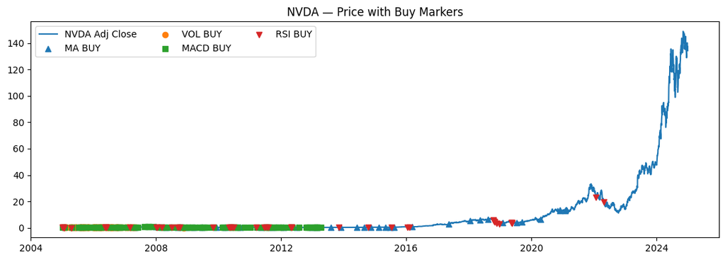

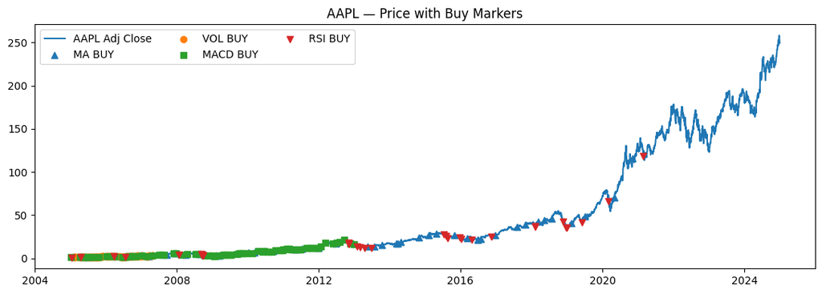

## Holdings over time

### benchmark strategy - holdings/cash/equity

The cash is a straight horizontal line since we invest and deploy all cash into all investable assets in 2005 such that there is nothing happened in cash. For holdings, since the time span 20 years with an obvious uptrends, which may be led by the information and AI age. From the chart below of holdings, we can find there are three main drawdowns corresponding to 2008(financial crisis,) 2020 covid period, and 2022 bear market.

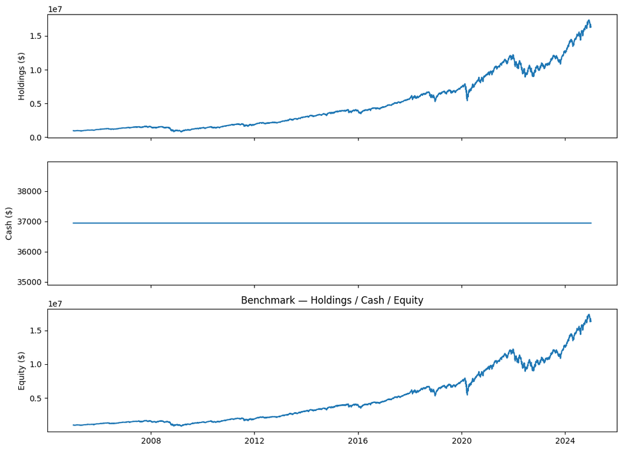

### Moving average strategy

There is an contrast direction for the chart of holdings and cash: as teh holdings go up, the cash goes down. This is because as we invest, the cash will decrease for sure, and the while bull market happened. And similar drawdowns happened as we talked above.

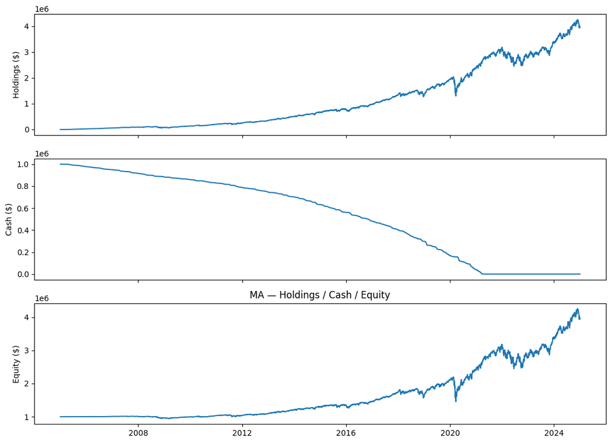

### Volatility breakout strategy

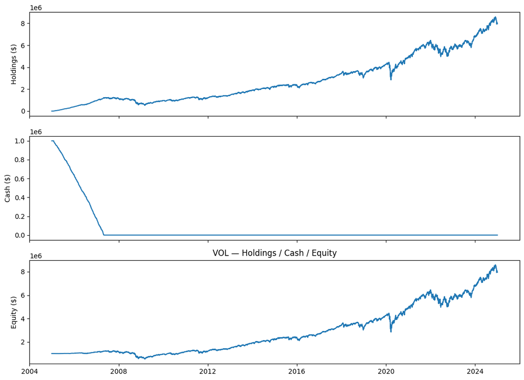

### MACD strategy

we can see the cash also decrease in the relatively early stage(but not as early as Volatility strategy), which might also be teh reason why the pnl lines of MACD is similar to the volatility breakout strategy.

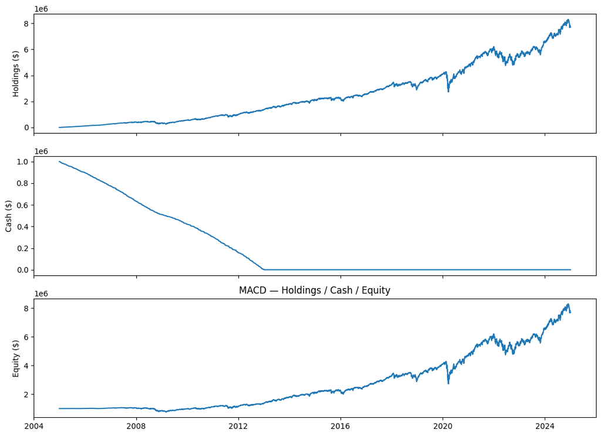

### RSI

We can see the cash is used up really late and the total onl is not so much as previous strategies.

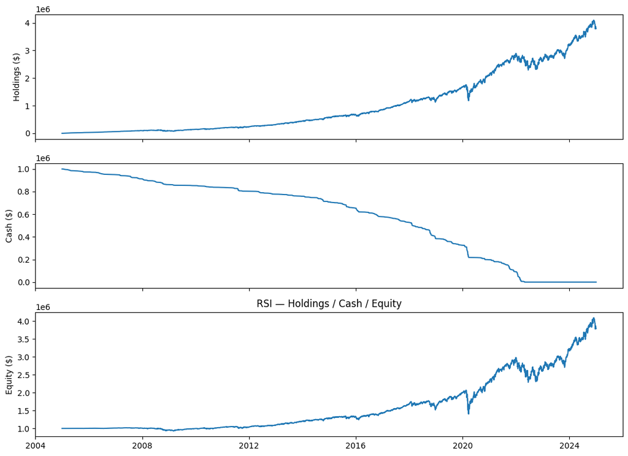

## Cumulative PnL comparison across strategies

VOL (green) and MACD (red) are the strongest of the signals. Both are trend/momentum-ish, both suffer in 2008–09 (GFC), 2020 (COVID crash), 2022 (bear market), then recover with trends.

MA (orange) and RSI (purple) are lowest:

- MA(20>50) trades only on cross events; between events we don’t add exposure so more cash drag.
- RSI(oversold) is mean-reversion; it buys into drawdowns and benefits from rebounds, but stays under-invested most of the time.

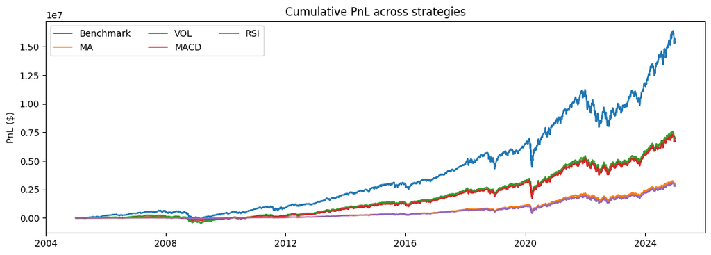

## Sumamry

|  | FinalPnL | AnnRet | AnnVol | Sharpe |
| --- | --- | --- | --- | --- |
| Benchmark | 1.534012e+07 | 0.172005 | 0.193760 | 0.887725 |
| MA | 2.948102e+06 | 0.078244 | 0.114343 | 0.684294 |
| VOL | 6.956580e+06 | 0.130661 | 0.194443 | 0.671972 |
| MACD | 6.696048e+06 | 0.120336 | 0.151075 | 0.796528 |
| RSI | 2.791500e+06 | 0.075680 | 0.111360 | 0.679594 |

From the table above and the chart I plot above, we can find PNL of benchmark(static strategy) is the highest; pnl of MACD strategy is similar to that of Volatility Breakout Strategy; meanwhile, the RSI strategy move close to the moving average strategy. The reason may be because we are investigating the long time range such that there exists many volatile things, especially such period is information age, as we can see the sharpe ratio of benchmark is also the highest.